# SESSION 2. ESTRUCTURAS DE DATOS Y FUNCIONES

Victor Miguel Terrón Macias

19/2/2021

# PREWORK. ESTRUCTURAS DE DATOS Y FUNCIONES

## LISTAS

Datos, datos, datos… Están en todas partes. Evidentemente, nosotros queremos aprender a analizarlos, así que entendemos su importancia. Cuando pensamos en datos solemos pensar en bases de datos, en archivos CSV, en hojas de Excel, y otros. Cada uno de estos tiene su propia estructura de datos. Las computadoras necesitan estas estructuras de datos para organizar los datos de manera eficiente. Sin estructuras de datos, tendríamos todos nuestros datos “regados por ahí”. Encontrar lo que estamos buscando sería imposible. Y todos nuestros procesos se harían de la forma más ineficiente posible. El día de hoy conoceremos dos de las estructuras de datos más básicas e importantes que tiene Python: las listas y los diccionarios. Listas Las listas son colecciones ordenadas de elementos. ¿De qué elementos hablamos? Bueno, en el caso de Python, prácticamente de lo que sea. ¿Recuerdas los tipos de datos que aprendimos en la sesión anterior? Pues cualquiera de esos puede ser incluido dentro de una lista. Si tenemos una serie de elementos que queremos guardar de forma ordenada, podemos meterlos dentro de una lista. Para crear una lista, usamos corchetes ([]) y luego colocamos nuestros elementos dentro de los corchetes. Así:

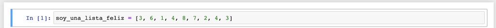

IMAGEN 1

Como puedes ver, el orden lo determino yo. Es decir, los números no están ordenados de menor a mayor. Yo decido en qué orden ponerlos y así se quedan. También podemos observar que es posible repetir elementos idénticos en diferentes lugares de la lista. En este caso hicimos una lista de ints, pero, como ya dijimos, podemos tener listas de prácticamente cualquier cosa:

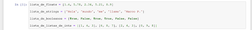

IMAGEN 2

Aunque en principio es posible, mezclar diferentes tipos de dato en una misma lista es una mala idea. Al hacerlo estamos haciendo más complicado procesar los datos que tenemos en esa lista. Es decir, va en contra de una de las razones principales que tenemos para usar estructuras de datos: la eficiencia. A veces es inevitable, pero debemos de evitarlo siempre que sea posible. Ok, ya tengo mi lista. ¿Ahora, cómo accedo a los elementos que tiene dentro? Toda lista tiene un índice ligado a cada elemento que la conforma. Como las listas son ordenadas, el índice empieza con 0 para el primer elemento, y luego va ascendiendo de uno en uno para los elementos subsecuentes. Podemos revisar la lista usando el operador de índice: [] . Lo usamos pasándole el índice del elemento al que quiero acceder:

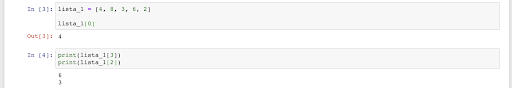

El orden de los elementos se mantiene a menos que algo lo modifique, así que la sentencia lista_1[0] me va a regresar siempre un 4 (el primer elemento de la lista), a menos que la lista sea modificada. Es importante tener cuidado cuando accedemos a índices en una lista. Si pedimos un índice que no está ligado a ningún elemento (porque es un índice mayor al número de elementos que tenemos en la lista), vamos a obtener un error (algo que no es buena idea obtener, como podrán imaginarse):

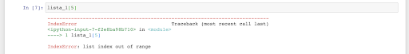

IMAGEN 5

## APPEND

Esto nos lleva a nuestra siguiente pregunta: ¿cómo es que modificamos una lista? Vamos a aprender 2 métodos básicos para modificar listas en Python: append y pop. Append Es una función que agrega un elemento al final de la lista. Llamamos append como hemos llamado otras funciones (print o type), usando paréntesis y pasándole dentro del paréntesis el elemento que queremos agregar a la lista. La única diferencia es que esta función la llamamos desde el objeto de la lista, con la sintaxis variable_que_contiene_tu_lista.append(). Es decir, variable_que_contiene_tu_lista + . + append + (). Porque esta función la llamamos desde el objeto de la lista, la nombramos método en vez de lista. No importa si no entiendes por qué en ese momento, pero yo voy a llamarles métodos a partir de ahora para ser correctos. Veamos append en acción:

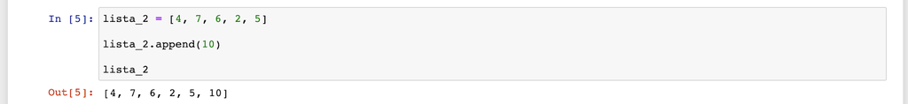

IMAGEN 6

### POP

Ya tenemos un método que agrega elementos a la lista. Ahora queremos quitar elementos de la lista, pop se utiliza justamente para eso. Si llamamos este método sin pasarle nada, pop remueve el último elemento de la lista:

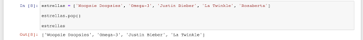

IMAGEN 8

Podemos pasarle un índice a pop para que remueva el elemento que está en ese índice:

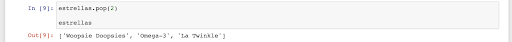

IMAGEN 9

## DICCIONARIOS

Los diccionarios se parecen bastante a los diccionarios léxicos. En un diccionario léxico, tienes pares de palabra-significado. si quieres saber el significado de una palabra, vas y buscas la palabra. Esa palabra está ligada a su significado. Por lo tanto, los diccionarios están organizados por pares. De igual manera, los diccionarios en Python están organizados en pares “llave-valor”. Cada llave tiene un valor asignado y para acceder al valor basta con pedir la llave. Una diferencia importante con los diccionarios léxicos es que los diccionarios en Python no están ordenados. Esto en realidad no importa demasiado, ya que buscar valores en un diccionario de Python es mucho más fácil y eficiente que en un diccionario léxico. ¿Y cómo es que creamos diccionarios? De esta manera:

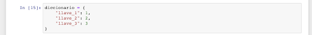

IMAGEN

Como ves, para crear diccionarios usamos llaves **{ }** en vez de corchetes. Después, escribimos el nombre de una llave y su respectivo valor separados por dos puntos (:). Cada par llave-valor está separado de los demás por comas. En este caso las llaves son strings, pero también podrían ser números:

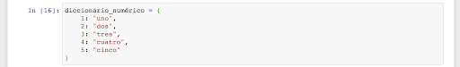

IMAGEN

Ahora, cómo accedemos a los valores que hemos guardado en nuestro diccionario. Es simple: usamos corchetes como con las listas, pero en vez de pasar un índice, pasamos el nombre de la llave:

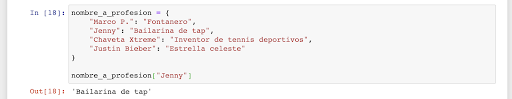

IMAGEN

Fácil, ¿no? Agregar datos Agregar datos a nuestros diccionarios es bastante sencillo. Para agregar un dato, se realiza una asignación como ésta:

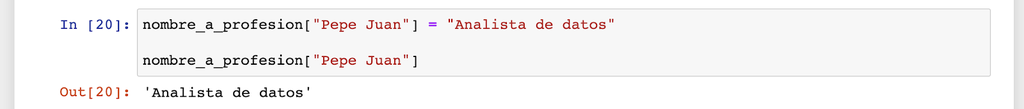

IMAGEN

Como ves, “selecciono” la llave que aún no existe y simplemente le paso el valor que le quiero asignar. Como se ve en la imagen, esa llave ahora existe en mi diccionario y puedo acceder a ella.

**Modificar datos**

También puedo modificar datos que ya se encuentran en mi diccionario. Para hacer esto, simplemente vuelo a asignar el nuevo valor a la llave que quiero modificar. Por ejemplo, digamos que Jenny acaba de cambiar de profesión. Podemos actualizar nuestro diccionario de la siguiente manera:

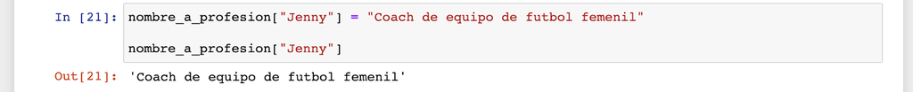

IMAGEN

Los valores de los diccionarios también pueden ser listas u otros diccionarios (¡Inception!). Por ejemplo, mira esto:

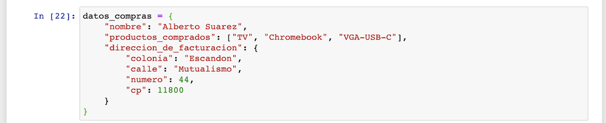

IMAGEN

En un caso como éste, también es posible modificar la lista y el diccionario que hay dentro. Es tan simple como pedir el valor y luego modificar ese valor (la lista o diccionario) con las técnicas que ya conocemos:

[figure not shown]

IMAGEN

Con esto terminamos la sección de estructuras de datos. Pasemos ahora a una de las herramientas más famosas y utilizadas en el mundo de la programación: las funciones.

## LAS FUNCIONES

Imaginemos que tenemos un código como éste (bueno, no hace falta imaginarlo, podemos escribirlo en nuestro JN):

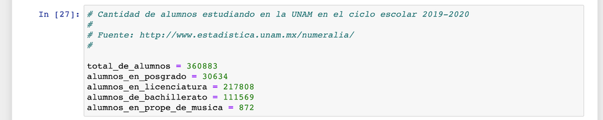

IMAGEN

Queremos saber el porcentaje del total de alumnos que estudian en cada uno de los niveles distintos. Un primer acercamiento podría ser éste:

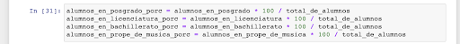

IMAGEN

No se ve tan mal, ¿verdad? Pues en realidad hay un problema más o menos grave: estamos repitiendo mucho código. Esa operación matemática para sacar el porcentaje, la regla de tres, ¡es exactamente igual siempre y la estamos escribiendo cuatro veces!

Si quiero sacar el porcentaje de otra estadística, tendría que volver a escribir la regla de tres. ¿Qué solución tengo? Crear una especie de “contenedor” donde tenga la lógica de mi operación, para que pueda repetir el proceso varias veces sin tener que volver a escribirlo. Justamente para eso sirven las funciones.

## SINTAXIS

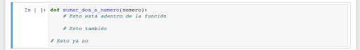

6. Escribir el proceso a seguir dentro de la indentación: 7. Retornar resultado

Finalmente quedandonos lo siguiente:

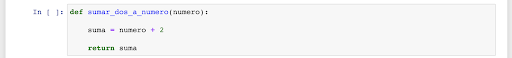

Por ejemplo tenemos la siguiente función:

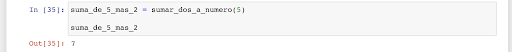

IMAGEN

¿Qué pasó aquí? Tengo una variable llamada suma_de_5_mas_2. A esta variable voy a asignarle el resultado de llamar mi función sumar_dos_a_numero con un 5 como argumento (se llaman parámetros dentro de la función pero argumentos a la hora de pasarlos… es confuso, lo sé). Dicho de otra manera: Llamo mi función sumar_dos_a_numero; le paso un 5 para que le sume 2; regreso el resultado de esa suma (7) y asigno ese resultado a una variable llamada suma_de_5_mas_2 que después puedo usar para lo que quiera (en este caso solamente estoy checando qué hay dentro de ella).

Lo interesante comienza cuando reutilizamos la función pasándole distintos argumentos:

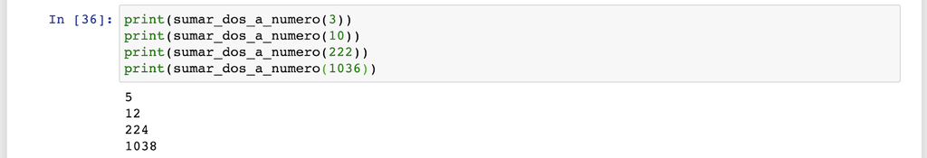

IMAGEN

En este caso estoy imprimiendo los resultados de las llamadas a sumar_dos_a_numero sin asignarlos antes a una variable.

## FUNCIÓN PARA CUANTIFICAR PORCENTAJES

Regresemos entonces a nuestro problema original: calcular los porcentajes del total de alumnos de la UNAM que estudian en cada nivel.

Vamos a construir una función que realice esta operación:

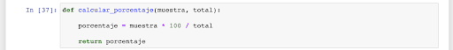

IMAGEN

Estoy declarando esta función con dos parámetros: muestra y total, muestra es el subconjunto del total que quiero expresar en porcentajes, total es el total de la población de mi conjunto de datos. Puedo declarar funciones con un número indeterminado de parámetros, cuantos sea que necesite, pero en general se recomienda mantener el número de parámetros a lo mínimo necesario. Entre menos parámetros, mejor.

Ahora sí, vamos a utilizar nuestra función:

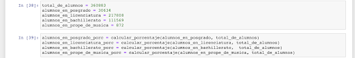

IMAGEN

En este caso pareciera que no estamos ahorrando tanto trabajo, ¿no? La cantidad de código que estamos escribiendo es prácticamente la misma. Pero imagina que el proceso de sacar porcentajes fuera mucho más largo y complicado.

En ese caso tendría mucho más sentido. Además, tenemos otras ventajas que voy a enumerar a continuación.

## OTRAS VENTAJAS DEL USO DE FUNCIONES

- Nuestra función tiene un nombre (calcular porcentaje). Por lo tanto, si alguien está leyendo nuestro código y no sabe que la operación para obtener el porcentaje es muestra * 100 / total, puede enterarse de ello a través del nombre de nuestra función. Es algo muy bueno hacer nuestro código lo más comprensible posible, ¡nunca sabemos quién más va a tener que leerlo y entenderlo además de nosotros!
- En caso de que descubramos una operación más eficiente para calcular el porcentaje (en este caso es muy poco probable que suceda, pero puede suceder fácilmente con funciones más complejas), lo único que tenemos que hacer es ir a nuestra función y cambiar el código que hay dentro. Automáticamente, el resto de nuestro código que está utilizando esta función va a utilizar la función optimizada. Si no hubiéramos escrito una función, tendríamos que buscar todos los lugares donde realizamos esa operación para cambiarlos. Una regla de oro en la programación es: ¡Nunca repitas código! A la hora de corregir errores u optimizar tu código, vas a agradecer no repetir código.
- En general es una buena idea pensar en nuestros programas modularmente. Esto significa pensarlo en los procesos más simples posibles y esos procesos encapsularlos en funciones (u otras estructuras). Separar nuestro código en “cachitos” va a hacerlo mucho más fácil de entender, corregir y aumentar.

## CONTEXTO DE LAS VARIABLES

Para terminar este Prework, vamos a hablar de algo llamado contexto en Python. contexto se refiere al área en tu código donde cada variable puede ser accesada. No todas las variables en tu código pueden ser accesadas desde cualquier lugar. Vamos a ver:

Tenemos una variable llamada variable_global. Esta variable fue asignada en lo que se llama el contexto global. Podemos saber que es el contexto global porque no hay ni un solo nivel de indentación antes del nombre de la variable. Al estar en el contexto global, esta variable puede ser accedida desde cualquier lugar, en la misma celda en la que fue asignada o en alguna otra celda distinta:

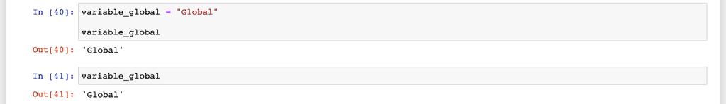

IMAGEN

Vemos ahora qué pasa con una variable declarada dentro de una sentencia if:

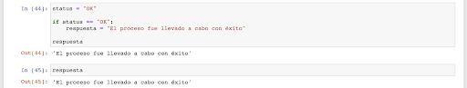

Como puedes ver, podemos acceder a la variable respuesta desde cualquier lugar. Eso quiere decir que en Python una sentencia if no cambia el contexto actual. Seguimos estando en el contexto desde el cual se declaró la sentencia if. Como esta sentencia se declaró en el contexto global, las variables que asignemos dentro del bloque de la sentencia seguirán teniendo contexto global.

# WORK. ESTRUCTURAS DE DATOS

## OBJETIVOS

1. Comprender la utilidad de las estructuras de datos para organizar información dentro de nuestros programas.
2. Utilizar listas y diccionarios y entender las principales diferencias entre ellos.
3. Declarar funciones y utilizarlas perfectamente